# Informe de Coyuntura de Cantabria

### Análisis y predicciones de la situación económica de Cantabria

#### Autores: Francisco Javier Martínez Márquez y José María Baca Daza

### ÍNDICE

1.Resumen

2.Actividad productiva

- Tasa de variación interanual del PIB de Cantabria y España
- Tasa de variación interanual del Índice de Producción Industrial
- Índice de confianza empresarial

3.Demanda

- Índice de confianza del consumidor en España
- Matriculaciones de turismos y motocicletas en España y Cantabria
- Viajeros en España y Cantabria
- Tasa de variación interanual de las exportaciones de España y Cantabria
- Tasa de variación interanual de las importaciones de España y Cantabria
- Balanza comercial en millones de euros

4.Mercado de Trabajo

- Tasa de actividad en España y Cantabria
- Tasa de empleo en España y Cantabria
- Tasa de paro en España y Cantabria
- Tasa de temporalidad en España y Cantabria
- Número de afiliados en España y Cantabria
- Tasa de variación interanual de las afiliaciones a la Seguridad Social
- Paro registrado en España y Cantabria
- Tasa de variación interanual del paro registrado en España y Cantabria

5.Precios y costes

- Tasa de variación interanual del IPC general y subyacente (inflación)
- Tasa de variación interanual de los costes salariales y no salariales en España y Cantabria

6.Impacto de la crisis y previsiones

- Estimación del efecto de la pandemia en las afiliaciones a la Seguridad Social en España y Cantabria
- Previsión de la tasa de paro para el cuarto trimestre de 2021

### 1. Resumen

Este informe analiza la situación económica de Cantabria durante el 4º trimestre de 2021.

Durante 2020 España sufrió una pandemia que sumergió al país en una crisis sanitaria y económica.

En el año 2021 se recuperó gran parte de la actividad económica, con tasas de crecimiento interanual del 15% del PIB.

Índice de Producción Industrial muestra una favorable recuperación con crecimientos de más del 40%.

El mercado de trabajo se encuentra con una tasa de paro en torno al 10% en el tercer trimestre de 2021, 4 puntos menos de lo que se alcanzó durante el segundo trimestre de 2020.

En 2021 se incrementó la inflación, más del 5%, aunque ocasionadas en su mayoría por el incremento del precio de la energía.

Se estima que la tasa de paro caerá al 13,59% en España y al 9,64% en Cantabria en el cuarto trimestre de 2021.

Se prevé que la recuperación observada durante 2021 continúe durante el año 2022 impulsada sobre todo por los fondos europeos y la inmunización de la población a través de las vacunas.

### 2. Actividad productiva

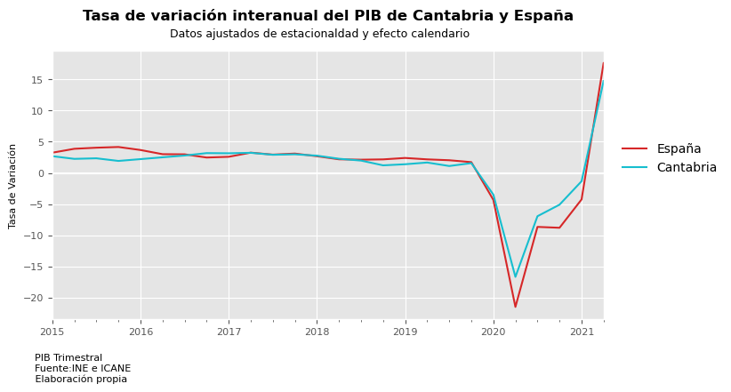

La pandemia tuvo un gran impacto en el PIB, llegando a caer más de un 20% en España y más de un 15% en Cantabria.

Desde el fin del confinamiento, las tasas de crecimiento son cada vez más positivas llegando en 2021 a tasas de crecimiento muy altas. Superando en el segundo trimestre de 2021 el 15% de crecimiento.

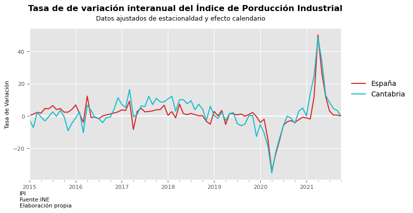

El IPI cayó tanto en España como en Cantabria un 30% en el segundo trimestre de 2020, tras el confinamiento.

Una vez acabado el confinamiento las tasas de crecimiento volvieron a su tendencia habitual.

En el segundo trimestre de 2021 las tasas de crecimiento crecieron tanto en España como en Cantabria hasta casi un 50%. En parte debido a la caída que tuvo en ese mismo trimestre en 2020.

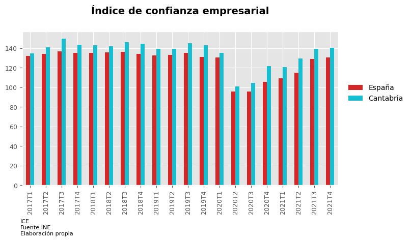

Durante la pandemia, el índice de confianza cayó alrededor de 30 puntos tanto en España como en Cantabria.

Este se ha ido recuperando conforme avanzaba el año 2020 recuperando ya los niveles que tenía antes de la pandemia a finales de 2021.

### 3. Demanda

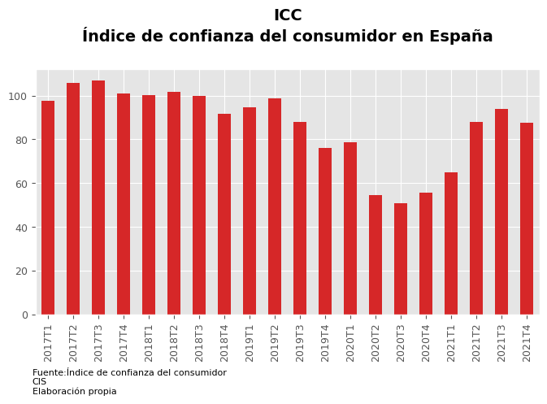

El índice de confianza del consumidor presentaba caídas en 2019, aunque en 2020 cayó algo más de 20 puntos.

En 2021 se empieza a recuperar el índice de confianza que había antes de la pandemia, situándose incluso por encima de los valores que tenía a finales de 2019.

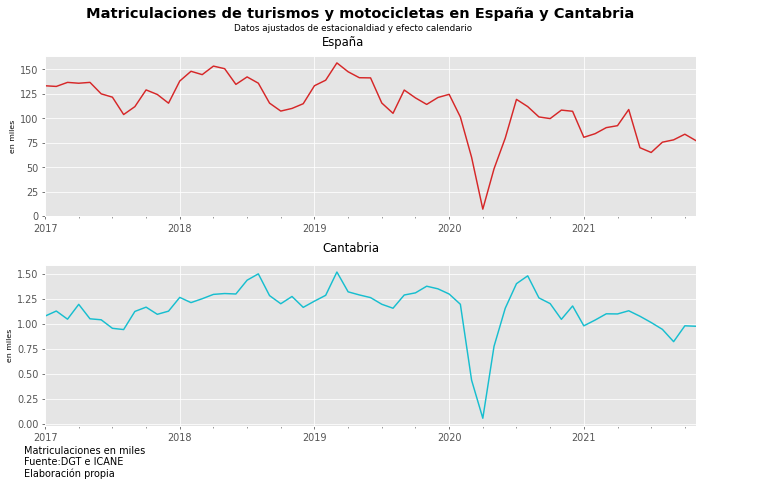

Las matriculaciones de turismos y motocicletas sufrieron una fuerte caída durante la pandemia tanto en España como Cantabria.

España y Cantabria presentaron un elevado crecimiento de las matriculaciones tras el desconfinamiento, sin embargo durante 2021 las matriculaciones se encuentran por debajo de los niveles anteriores a la pandemia.

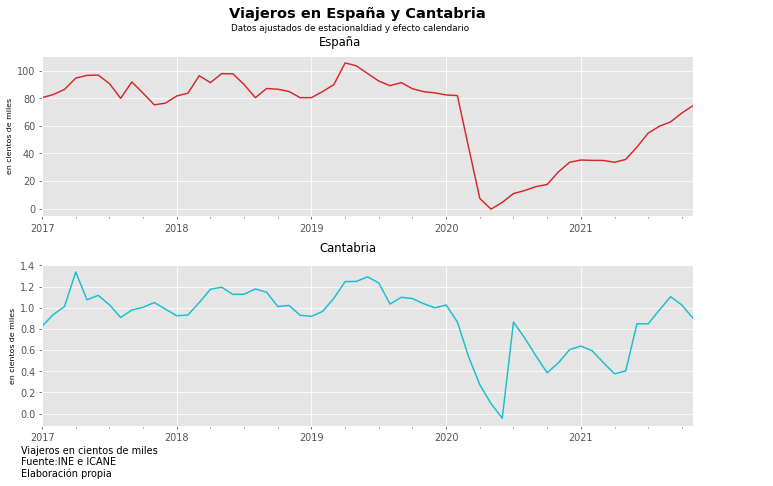

Con la aparición de la pandemia y el confinamiento, los viajeros cayeron a 0 en ambas gráficas.

Con el desconfinamiento Cantabria recibió una cifra de viajeros similar al que solía tener antes de la pandemia, recuperando de hecho este número de viajeros en 2021.

España sin embargo obtuvo un número de viajeros mucho menor en 2020 en comparación a otros años. Y aún en 2021 no ha conseguido alcanzar las cifras de antes de la pandemia.

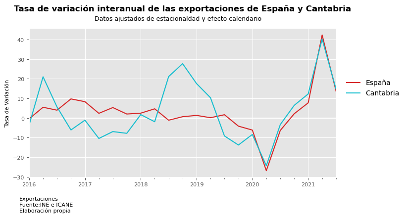

En el segundo trimestre de 2020 las exportaciones cayeron más de un 20%.

Desde entonces estas han ido creciendo, teniendo Cantabria una tasa de crecimiento mayor durante 2020. Aunque en 2021 las exportaciones crecían igual tanto en España como en Cantabria.

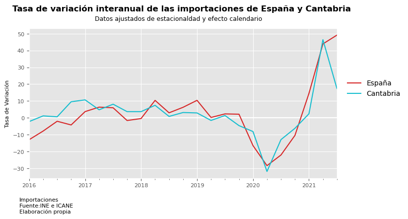

Las tasas de crecimiento de las importaciones tienen una evolución similar tanto en España como en Cantabria.

En 2020 cayeron hasta un 30% en Cantabria y casi lo mismo en España.

Desde entonces han ido creciendo hasta alcanzar el segundo trimestre de 2021 un crecimiento de más del 40%, que luego cayó en el siguiente trimestre en Cantabria pero que alcanzó el 50% de crecimiento en España.

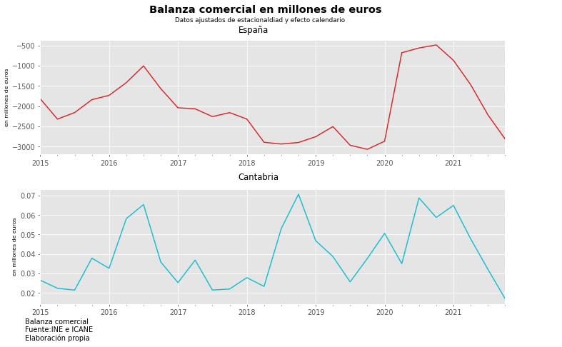

Cantabria presenta una balanza comercial positiva a diferencia de España.

En el confinamiento en España la balanza comercial mejoró mientras que en Cantabria empeoró un poco (aunque luego mejorara).

Desde el cuarto trimestre de 2020 hasta el cuarto de 2021 la balanza comercial ha ido empeorando tanto en España como en Cantabria.

### 4. Mercado de trabajo

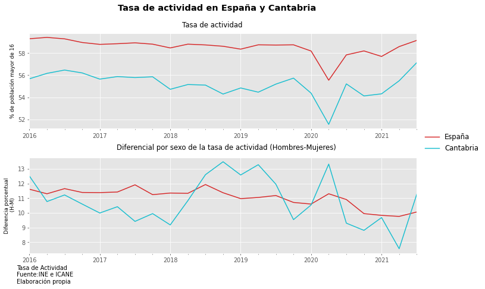

La tasa de actividad es en torno a 3 puntos porcentuales mayor en España que en Cantabria.

La tasa de actividad cayó en 2 puntos en España y 4 en Cantabria en el segundo trimestre de 2020. Se ha ido recuperando desde entonces llegando a tener valores en el tercer trimestre de 2021 más altos de los que tenía antes de la pandemia.

Tanto en España como en Cantabria el diferencial por sexo de la tasa de actividad es positiva, es decir, que la tasa de actividad es mayor en hombres que en mujeres. El diferencial se mantiene constante en España (incluso durante la pandemia) mientras que en Cantabria presenta una mayor inestabilidad.

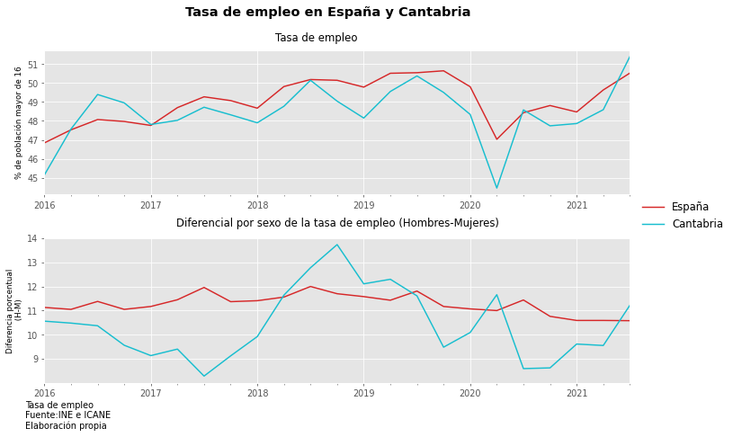

La pandemia redujo la tasa de empleo en torno a los 4 puntos en España y Cantabria. Con el fin de las restricciones la tasa de empleo se ha ido recuperando, alcanzado los valores de antes de la pandemia en España y superiores a estos en Cantabria (llegando a superar a la tasa de empleo en España).

Tanto en España como en Cantabria el diferencial por sexo de la tasa de empleo es positiva, es decir, que la tasa de empleo es mayor en hombres que en mujeres.

El diferencial es normalmente menor en Cantabria que en España, a excepción de 2018 y durante el confinamiento. En España la pandemia no ha tenido un impacto en este diferencial.

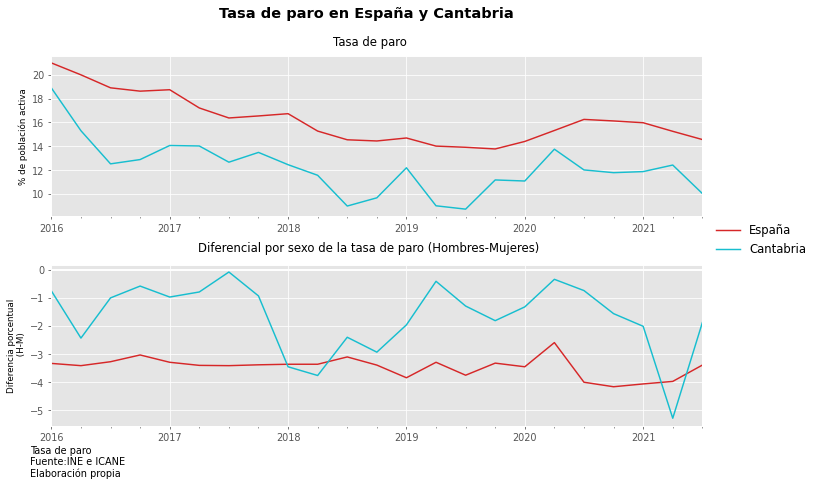

La tasa de paro es menor en Cantabria que en España en unos 4 puntos. Durante la pandemia la tasa de paro aumentó tanto en España como en Cantabria.

En 2021 la tasa de paro se ha reducido en España y en Cantabria hasta niveles similares a antes de la pandemia. En Cantabria la caída de la tasa de paro fue mayor que en España.

En este caso en el diferencial se observa como las mujeres presentan mayores tasas de paro que los hombres, aunque esta desigualdad es menor en Cantabria. Después de la pandemia tanto en España como en Cantabria el diferencial ha caído por debajo de los niveles que tenía antes.

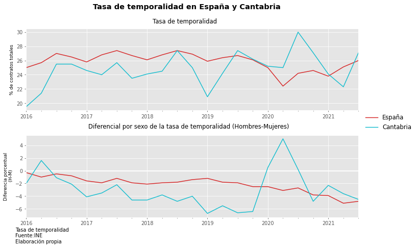

La tasa de temporalidad ha estado por debajo en Cantabria hasta mediados de 2020. La pandemia aumentó los contratos temporales en Cantabria, pero los redujo en España. En 2021 se ha vuelto a la misma tasa de temporalidad en España y Cantabria que antes de la pandemia.

El diferencial entre hombres y mujeres es negativo y ha ido decreciendo en España y en Cantabria. Durante el confinamiento esta diferencia se invirtió en Cantabria, aunque luego volvió a valores negativos.

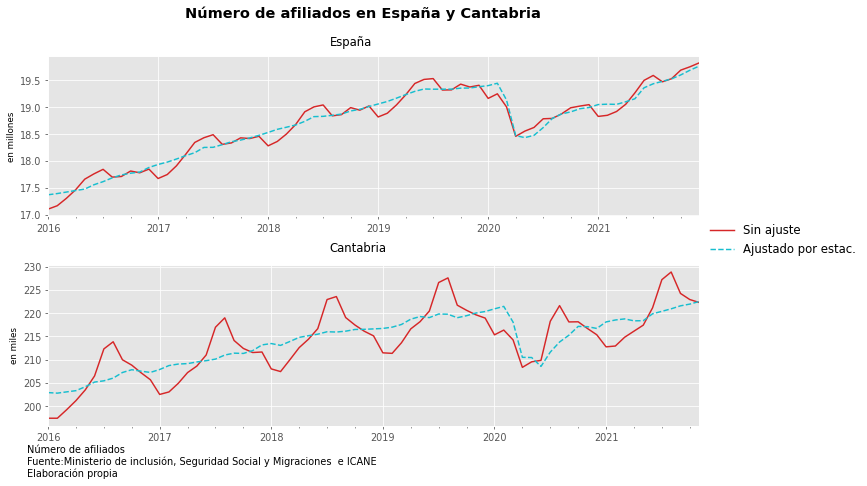

El número de afiliados ha ido creciendo de forma gradual tanto en España como Cantabria.

En 2020 debido al COVID-19 el número de afiliados cayó a los niveles que tenía en 2018.

Actualmente en 2021 las afiliaciones a la Seguridad Social son superiores a los niveles prepandemia.

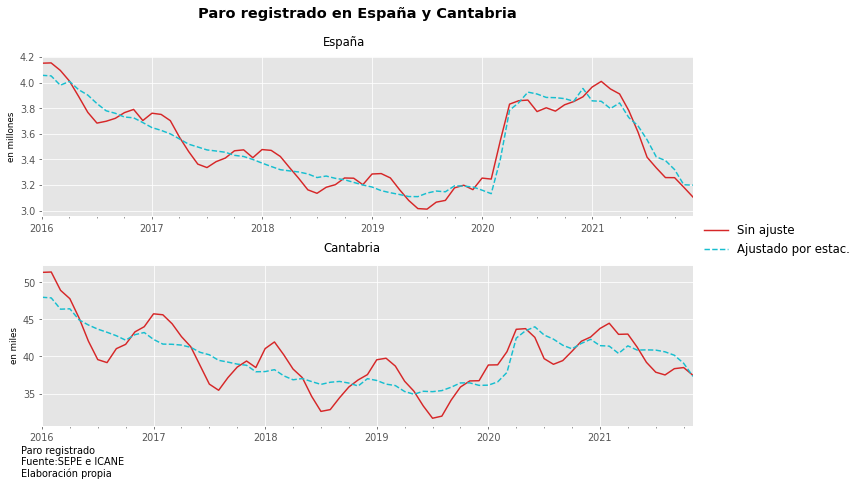

El paro registrado estaba siguiendo un descenso desde 2016 tanto en Cantabria como en España.

La aparición del COVID-19 en 2020 aumentó el paro registrado alcanzando en España los casi 4 millones y en Cantabria superando los 40 mil.

En 2021 España ha reducido considerablemente el paro registrado estando este en los niveles prepandemia. En Cantabria aún estaría un poco por encima.

### 5. Precios y costes

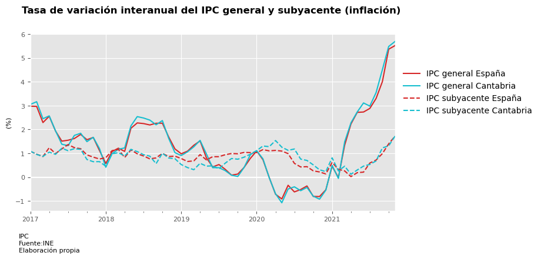

La inflación llevaba una tendencia a la baja desde inicios de 2019, cayendo por debajo del 1%. La inflación subyacente se ha situado en torno al 1% hasta el 2020.

En 2020 tras el parón económico, la inflación alcanzó tasas negativas de crecimiento. El subyacente, que también bajó del 1%, no llegó a tener tasas negativas.

En 2021 la inflación se ha disparado hasta más del 5% en el cuarto trimestre de 2021. La subyacente sin embargo, aunque también ha crecido, no llega al 2%. Lo que nos indica que son los productos energéticos los principales causantes de esta inflación.

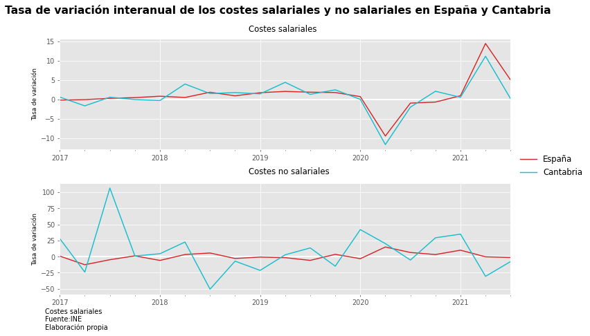

La tasa de variación de los costes salariales tienen una evolución similar en España y Cantabria. Hasta 2020 venían creciendo por debajo del 5%.

En 2020 debido a la pandemia los costes cayeron por más de un 10%. Desde entonces han crecido, situándose en 2021 por encima del 10% de crecimiento en el segundo trimestre de 2021, para luego volver a sus tasas de crecimiento habituales.

### 6. Impacto de la crisis y previsiones

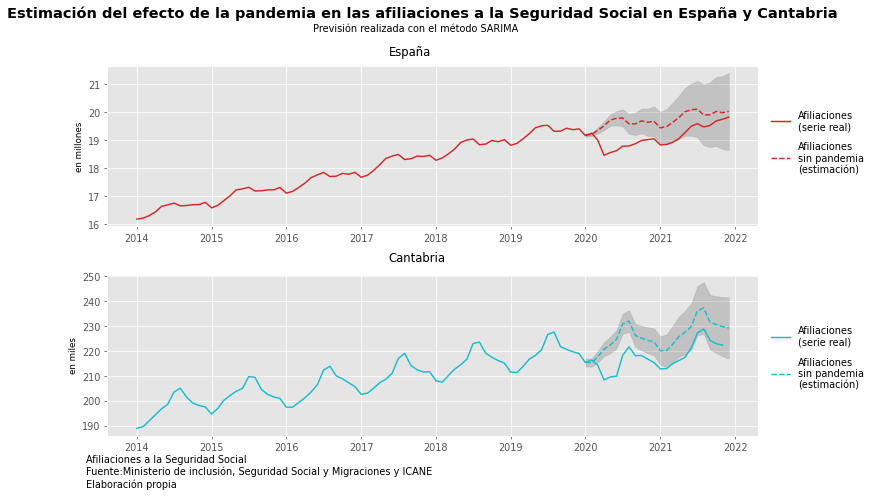

Las afiliaciones a la Seguridad Social habrían continuado su tendencia creciente sin la situación de la pandemia. Llegando en España a los 20 millones de afiliaciones, y a 230 mil en Cantabria.

En 2021 en España casi se habría alcanzado el número de afiliados que se preveían sin pandemia para ese año. Cantabria, sin embargo, aún estaría lejos de alcanzar esta cifra.

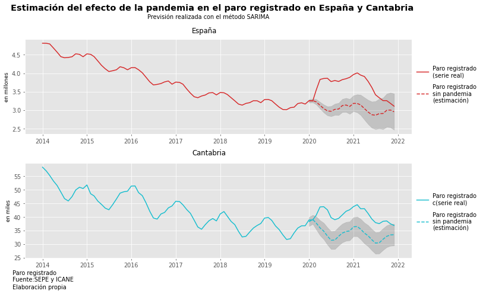

El paro habría continuado su senda de decrecimiento sin pandemia. Llegando en 2021 a tener algo menos de 3 millones de parados en España y menos de 35 mil en Cantabria.

En 2020 el Covid-19 provocó una diferencia de casi 1 millón de parados entre los parados estimados sin pandemia y los que se acabaron registrando. En Cantabria esta diferencia fue de casi 10 mil.

En 2021 España tendría un paro registrado algo mayor del que se estimaba sin pandemia para ese año al igual que Cantabria.

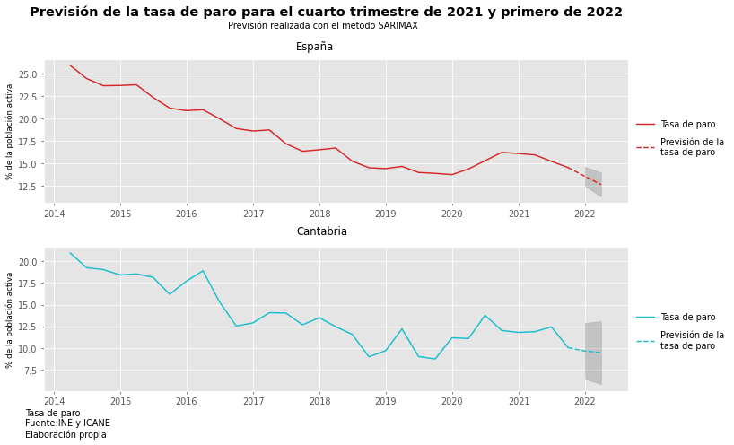

Después del aumento de la tasa de paro en 2020, esta ha ido decreciendo.

En el tercer trimestre de 2021 la tasa de paro en España era del 14,57%, la previsión para el cuarto trimestre es una tasa de paro del 13,59%.

En el tercer trimestre de 2021 Cantabria presentaba una tasa de paro del 10,04%, la previsión para el cuarto trimestre es del 9,64%.

La previsión para el primer trimestre de 2022 es de 9,46% en Cantabria y del 12,66% en España.

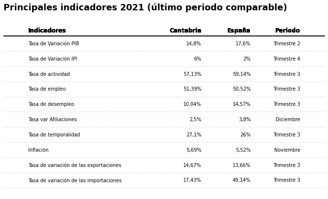